# Lab 1 Answers: Intro to R

## Exercise 6

Make a plot that displays the proportion of boys born over time. What do you see? Does Arbuthnot’s observation about boys being born in greater proportion than girls hold up in the U.S.? Include the plot in your response. Hint: You should be able to reuse your code from Exercise 3 above, just replace the name of the data frame.

### Answer

The code for their plots might differ from mine, but the plot should be the same. Unless they made a dot plot instead of a line plot, which is also fine.

It appears that Arbuthnot’s observation about boys being born in greater proportion than girls holds up in the U.S.

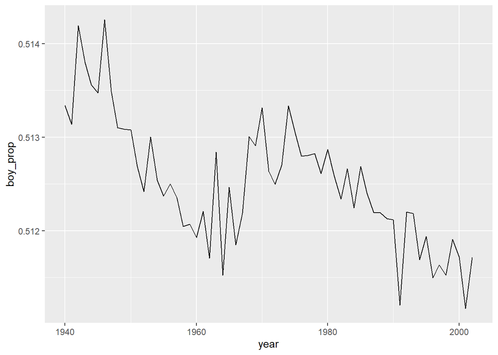

```r
present %>%
  mutate(boy_prop = boys/(boys+girls)) %>%
  ggplot(aes(x = year, y = boy_prop)) +
  geom_line()
```

### Grading

3 points for the plot, 2 points for observing that boys are born in higher proportion than girls in the US, 1 point for communication.

```r
points = points + 3 + 2 + 1
```

## Exercise 7

Create a new variable for the present data called total that adds up boys and girls just like we did with arbuthnot’s. For this question, you only need to present the code you used as an code chunk.

### Answer

```r
present <- present %>%
  mutate(total = boys + girls)
```

### Grading

3 points for code similar to mine that works.

```r
points = points + 3
```

## Exercise 8

In what year did we see the most total number of births in the U.S.? Hint: Sort your dataset in descending order based on the total column. You can do this interactively in the data viewer by clicking on the arrows next to the variable names. To include the sorted result in your report you will need to use two new functions. First we use arrange() to sorting the variable. Then we can arrange the data in a descending order with another function, desc(), for descending order. The sample code is provided below.

### Answer

The code below shows 1961 was the year with the highest number of total births.

```r
present %>%
  arrange(desc(total))
```

```
## # A tibble: 63 x 4
##     year    boys   girls   total
##    <dbl>   <dbl>   <dbl>   <dbl>
##  1  1961 2186274 2082052 4268326
##  2  1960 2179708 2078142 4257850
##  3  1957 2179960 2074824 4254784
##  4  1959 2173638 2071158 4244796
##  5  1958 2152546 2051266 4203812
##  6  1962 2132466 2034896 4167362
##  7  1956 2133588 2029502 4163090
##  8  1990 2129495 2028717 4158212
##  9  1991 2101518 2009389 4110907
## 10  1963 2101632 1996388 4098020
## # ... with 53 more rows
```

### Grading

3 points for 1961. 1 point for including code. 1 point for communication.

```r
points = points + 3 + 1 + 1
```

## Exercise 9

Use complete sentence(s) to tell me when you need to install packages and when you need to load packages with the library function.

### Answer

You only need to install packages once on a computer. You need to load packages you need each time you start R.

### Grading

1 point for installing once. 1 point for loading each time. 1 point for communication.

```r
points = points + 1 + 1 + 1
```

## Exercise 10

Use complete sentence(s) to tell me the three ways to view data.

### Answer

One way to view data is to use the code `View(your-data-frame)`. A second way to view data is to click on the name of the data set in the “Envirorment” pane. A third way to view data is simply to put it’s name in the console such as `your-data-frame.`

### Grading

1 point for each way. 1 point for communication.

```r
points = points + 3 +  1
```

## Total Points: 48